# Clase 04 Guía Variables Aleatorias Discretas

Dr. José Gallardo Matus. | Pontificia Universidad Católica de Valparaíso | jose.gallardo@pucv.cl

31 August 2021

```r
knitr::opts_chunk$set(echo = TRUE)

# Librería de "stats" y "graphics" están instaladas en la base de R
library(stats)
library(graphics)

# Librería Pander desde "knit" Permite crear tablas con leyendas en Rmarkdown
library(pander)

# Librería MASS contiene funciones de apoyo para trabajar con el libro de Venables and Ripley llamado Modern Applied Statistics with S (2002)
library(MASS)
```

#### **Introducción**

**¿Cuál es la diferencia entre variable y dato?**

Las **variables** son las características que se pueden medir en un individuo o en un ambiente y los **datos** son los valores que puede tomar esa variable.

**¿Qué es una variable aleatoria?**

Es una variable cuyo valor se determina por el azar. Las variables aleatorias se representan por letras mayúsculas (**X**) y sus valores numéricos por letras minúsculas ($x_i$).

#### **Clasificación de variables cuantitativas**

[output not shown]

#### **Clasificación de variables cualitativas o categóricas**

| Tipo de variable | Descripción |
| --- | --- |
| **Variables nominales:** | Sus valores representan categorías que no obedecen a una clasificación intrínseca. |
| **Variables ordinales:** | Sus valores representan categorías con alguna clasificación intrínseca. |

### **Distribución de una variable**

*Distribución empírica (observación)*: Los datos de una muestra, obtenidos de forma aleatoria de una población, pueden ser usados para observar su comportamiento o distribución.

*Distribución de probabilidad (predicción)*: Las variables aleatorias tienen diferentes distribuciones de probabilidad subyacentes, lo que nos permite predecir su comportamiento y realizar inferencia estadística.

Las variables cuantitativas continuas usualmente tienen una *Distribución normal*. En cambio las variables discretas tienen otros tipos de distribución como *Bernoulli, Binomial, Binomial Negativa, Poisson, entre otras*.

#### **Objetivos de aprendizaje**

Los objetivos de aprendizaje de esta guía son:

**1**. Observar y predecir el comportamiento de variables aleatorias discretas con distribución Bernoulli o Binomial.

**2**. Elaborar un reporte dinámico en formato pdf.

## **Funciones clave para simular variables aleatorias discretas**

1.- Establece una semilla o punto de inicio para la generación de números aleatorios. Permite obtener resultados reproducibles cada vez. **set.seed()**

2.- Genera (n) números aleatorios para la distribución binomial con parámetros tamaño (size) y probabilidad de éxito de un ensayo (probe). **rbinom(n, size, prob)**

3.- Genera (n) números aleatorios para la distribución de binomial negativa con parámetros promedio (mu) y varianza (mu + mu^2 / theta). **rnegbin (n, mu, theta)**

### EJERCICIOS VARIABLE ALEATORIA DISCRETA CON DISTRIBUCIÓN BINOMIAL NEGATIVA.

La abundancia de parásitos como el piojo de mar *Caligus rogercresseyi* en los salmones silvestres y de cultivo puede ser considerada como una variable distreta con distribución binomial negativa. Esto significa que uno suele observar muchos peces con pocos parásitos (ej= 0 o 1) y pocos peces con muchos parásitos. Un estudio demostró que el promedio de la abundancia de parásitos fue de 25 con un rango de 0 a 100.

Como en la clase anterior para resolver los ejercicios debe crear su propio *script*. En **Rstudio.cloud** seleccione **File > New file > R Markdown**. Complete la información estandar de metadatos: Título, nombre del autor y seleccione pdf. Luego guarde inmediatamente su script como **script_4_nombre_apellido.Rmd**. Al finalizar la actividad deberá entregar su tarea.

**Ejercicio 1.** Cree un objeto llamado “caligus” para representar el número de parásitos en los peces. Simule una muestra aletoria con distribución binomial negativa con la función rnegbin(). Considere 1000 peces con una media de 25 parásitos. Para simular la varianza debe asignar valores arbitrarios a theta entre 1 y 5 hasta obtener un promedio y rango aproximado al estudio antes descrito.

Generar una muestra desde la población en estudio

```r
set.seed(123)
# n = 1000 animales
# mu = 25 (parásitos por pez)
# theta = 1 (cambie este valor hasta encontrar uno que se ajuste a los datos observados)
caligus <- rnegbin (1000, 25, 3)
head(caligus, 20)
```

```
##  [1] 17 42  3 24 50 25 10  4 46 26 23 28 17 43 36 30 21 16  8 25
```

```r
mean(caligus)
```

```
## [1] 23.74
```

**Ejercicio 2.** a) Use las funciones head() y range() para observar sus datos. Compare las funciones quantile() y summary().

```r
head(caligus)
```

```
## [1] 17 42  3 24 50 25
```

```r
range(caligus)
```

```
## [1]  0 98
```

```r
quantile(caligus)
```

```
##   0%  25%  50%  75% 100%
##    0   13   21   31   98
```

```r
summary(caligus)
```

```
##    Min. 1st Qu.  Median    Mean 3rd Qu.    Max.
##    0.00   13.00   21.00   23.74   31.00   98.00
```

2. ¿Que parámetro representa mejor los datos, la mediana o la media?

```r
"La mediana representa mejor los datos puesto que la media es muy influenciable por los valores extremos"
```

```
## [1] "La mediana representa mejor los datos puesto que la media es muy influenciable por los valores extremos"
```

**Ejercicio 3.** A partir de la simulación anterior elabore un histograma y una gráfica de cajas y bigotes. Use la función par(mfrow=c(1,2)) para generar las gráficas en una sola fila y con 2 columnas.

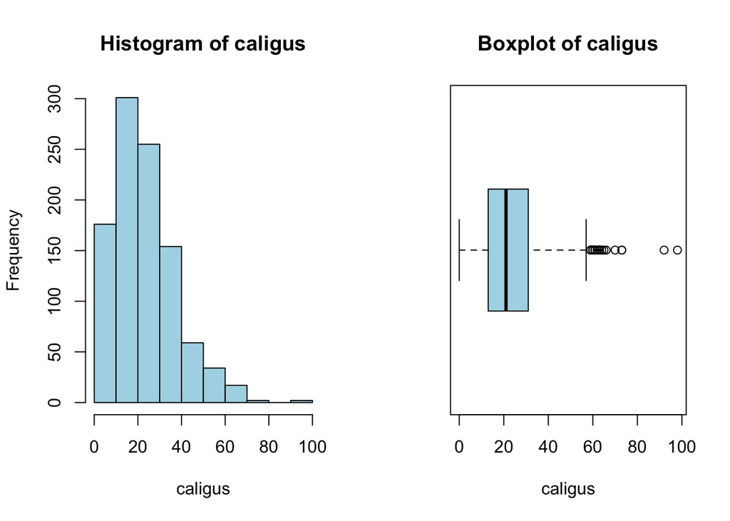

```r
par(mfrow=c(1,2))
hist(caligus, col="lightblue")
boxplot(caligus, col="lightblue", main="Boxplot of caligus", horizontal = TRUE, xlab="caligus")
```

**Ejercicio 4.** A partir de la simulación del número de parásitos y usando la función plot() elabore:

1. Gráfica con la distribución acumulada empírica. Debe incluir la función scdf().

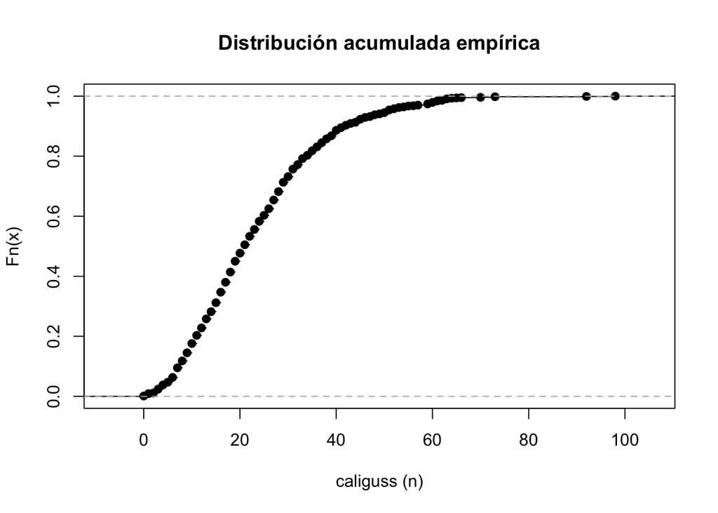

```r
# Distribución acumulada empírica.
plot(ecdf(caligus), main="Distribución acumulada empírica", xlab="caliguss (n)")
```

2. Gráfica con la densidad empírica. Debe incluir la función density().

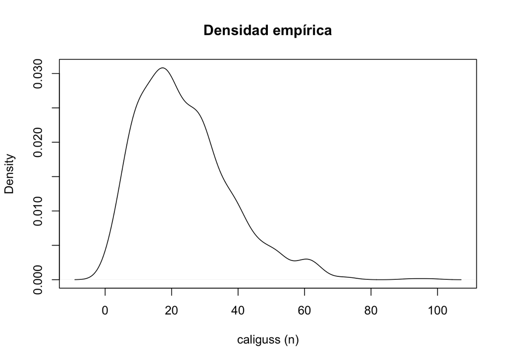

```r
# Densidad empírica.
plot(density(caligus), main="Densidad empírica", xlab="caliguss (n)")
```

**Ejercicio 5.** En una sola gráfica combine un histograma hist() y una función de densidad de los datos simulados lines(density()).

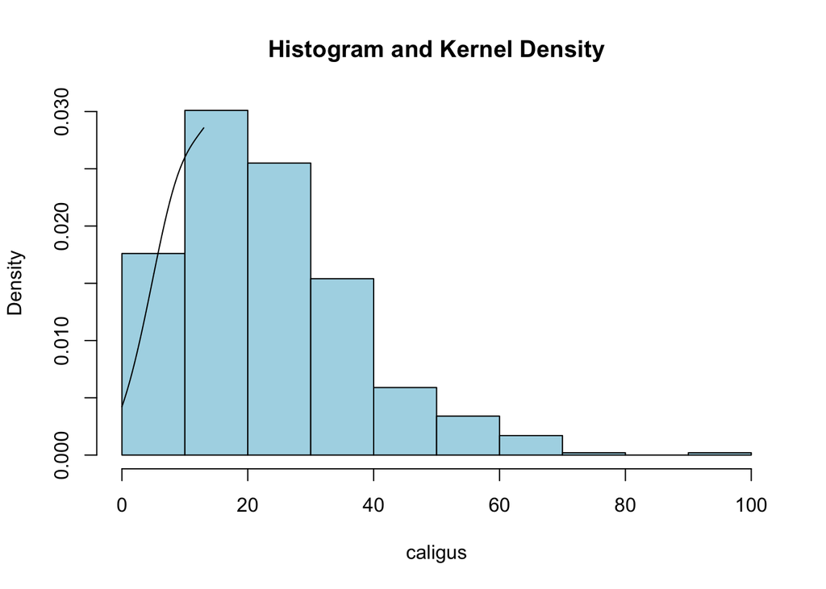

```r
hist(caligus, probability = TRUE, col="lightblue", main = "Histogram and Kernel Density")
lines(density(caligus, from = 0, to = 13))
```

### EJERCICIOS VARIABLE ALEATORIA DISCRETA CON DISTRIBUCIÓN BINOMIAL.

*Alexandrium catenella* es una microalga tóxica que produce el veneno paralizante de los mariscos (VPM). En Chile las intoxicaciones por VPM entre 1972-2002 generaron 456 enfermos y 30 fallecidos (total = 486). A partir de estos antecedentes responda.

**Ejercicio 6.** ¿Cuál es la letalidad por VPM en Chile?

```r
30 / 486
```

```
## [1] 0.0617284
```

**Ejercicio 7.** ¿Que tipo de variable y distribución mejor representa a la intoxicación por VPM?

```r
"Variable Discreta"
```

```
## [1] "Variable Discreta"
```

```r
"Distribución Bernoulli"
```

```
## [1] "Distribución Bernoulli"
```

**Ejercicio 8.** Se ha reportado un intoxicación masiva en una caleta Portales de Valparaíso que dió como resultado 80 personas intoxicadas.

1. ¿Cuántas personas se recuperarán (0) y cuantas morirán (1) por esta intoxicación?.

Para responder primero cree un objeto denominado **rvpm* y simule el resultado de la intoxicación usando rbinom(). Recuerde usar set.seed(123) y la tasa de letalidad calculada anteriormente. Use print() para observar sus datos simulados.

```r
set.seed(123)
n <- 80
p <- 0.0617
q <- 1-p
rvpm<-rbinom(n, size=1, prob=0.0617)
print(rvpm)
```

```
##  [1] 0 0 0 0 1 0 0 0 0 0 1 0 0 0 0 0 0 0 0 1 0 0 0 1 0 0 0 0 0 0 1 0 0 0 0 0 0 0
## [39] 0 0 0 0 0 0 0 0 0 0 0 0 0 0 0 0 0 0 0 0 0 0 0 0 0 0 0 0 0 0 0 0 0 0 0 0 0 0
## [77] 0 0 0 0
```

2. Represente en una tabla la frecuencia esperada de recuperados y fallecidos

```r
table(rvpm)
```

```
## rvpm
##  0  1
## 75  5
```

```r
#Tabla con formato para reporte

knitr::kable(
  table(rvpm),
  row.names = TRUE
  , caption = "Tabla de frecuencia de Recuperados (0) versus fallecidos (1)")
```

Tabla de frecuencia de Recuperados (0) versus fallecidos (1)

|  | rvpm | Freq |
| --- | --- | --- |
| 1 | 0 | 75 |
| 2 | 1 | 5 |

3. Represente en un histograma la frecuencia de recuperados y fallecidos

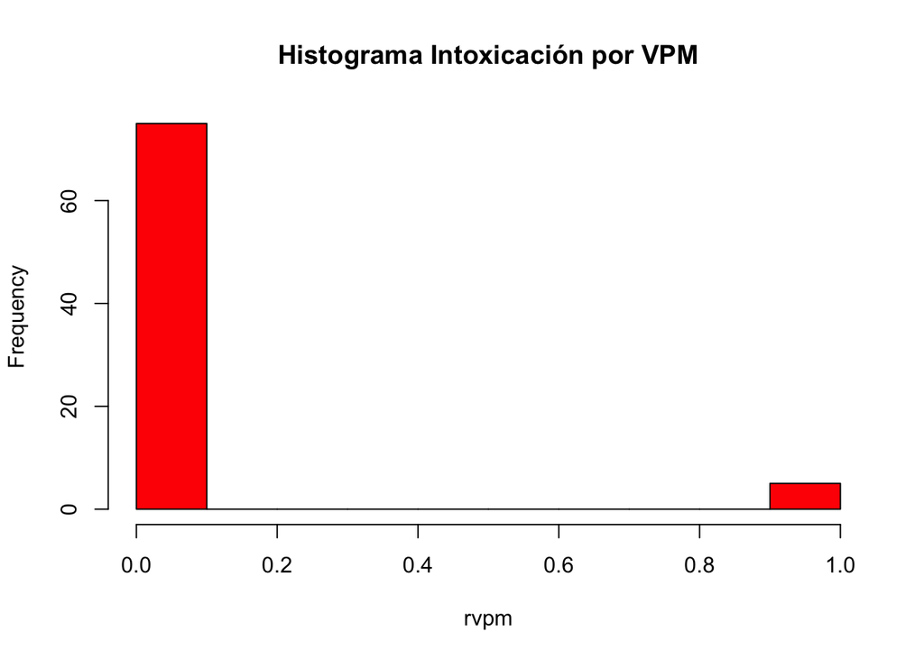

```r
hist(rvpm, col="red", main = "Histograma Intoxicación por VPM")
```

**Ejercicio 9.** Investigue como se calcula el promedio y la varianza de una variable con distribución binomial. Calcule ambos parámetros para la población de estudio.

Promedio de fallecidos

```r
n*p
```

```
## [1] 4.936
```

Varianza de fallecidos

```r
n*p*q
```

```
## [1] 4.631449
```

**Ejercicio 10.** Grafique función de densidad de las intoxicaciones por VPM usando una la función plot. En el eje “x” grafique los datos simulados con rbinom() y en el eje “y” la función de densidad dbinom().

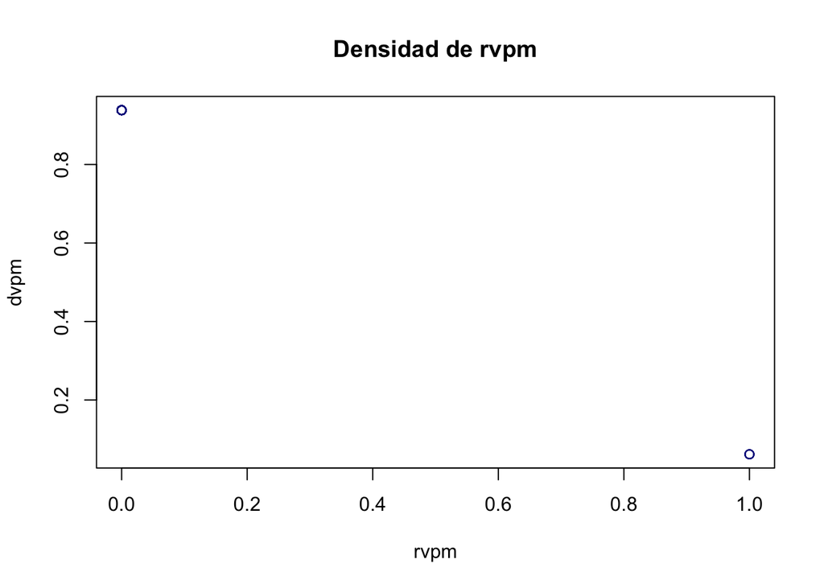

```r
dvpm<-dbinom(rvpm, size=1, prob=0.0617)
plot(x=rvpm, y=dvpm, main="Densidad de rvpm", col="blue4")
```

**Ejercicio 11.** Grafique la distribución de probabilidad acumulada de las intoxicaciones por VPM usando la función plot(). En el eje “x” grafique los datos simulados con rbinom() y en el eje “y” la probabilidad acumulada con pbinom().

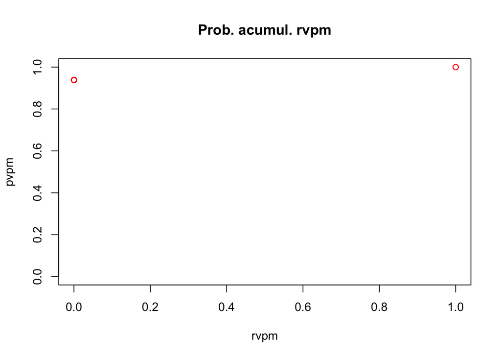

```r
pvpm<-pbinom(rvpm, size=1, prob=0.0617)
plot(x=rvpm, y=pvpm, main="Prob. acumul. rvpm", col="red", ylim=c(0,1))
```

**Ejercicio 11.** Use la función qqnorm para chequear la normalidad de los datos. Interprete su resultado.

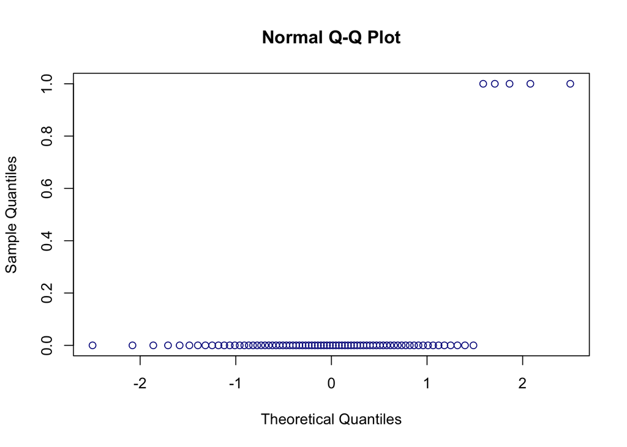

```r
qqnorm(rvpm, col="blue4")
```

```r
# No se observa un patrón de distribución normal como el observado para variables cuantitativas continuas.
```